# Reproducible Research: Peer Assessment 1

cs

12/6/2020

## Loading and Preprocessing the Data

First, we’ll load the Tidyverse library to help with both data processing and plotting. Then we’ll create a temporary file, download and unzip the data, and use the read.csv function to load it into a dataframe.

```r
knitr::opts_chunk$set(echo = TRUE)
library(tidyverse)
```

```r
temp <- tempfile()
fileurl <- "https://d396qusza40orc.cloudfront.net/repdata%2Fdata%2Factivity.zip"
download.file(fileurl, temp)
df <- read.csv(unz(temp, "activity.csv"))
unlink(temp)
summary(df)
```

```
##      steps            date              interval
##  Min.   :  0.00   Length:17568       Min.   :   0.0
##  1st Qu.:  0.00   Class :character   1st Qu.: 588.8
##  Median :  0.00   Mode  :character   Median :1177.5
##  Mean   : 37.38                      Mean   :1177.5
##  3rd Qu.: 12.00                      3rd Qu.:1766.2
##  Max.   :806.00                      Max.   :2355.0
##  NA's   :2304
```

```r
head(df)
```

```
##   steps       date interval
## 1    NA 2012-10-01        0
## 2    NA 2012-10-01        5
## 3    NA 2012-10-01       10
## 4    NA 2012-10-01       15
## 5    NA 2012-10-01       20
## 6    NA 2012-10-01       25
```

##What is mean total number of steps taken per day?

I’ve created a grouped dataframe by date based on our original data and then used the summarise function to total the steps per day. The histogram was created with ggplot and based off of the new dataframe.

The histogram shows the distribution of steps per day - there’s a clear peak at about 10k steps. Accordingly, the mean steps per day is 10766 and the median is 10765.

```r
df1 <- df %>% group_by(date) %>% summarise(total=sum(steps))
```

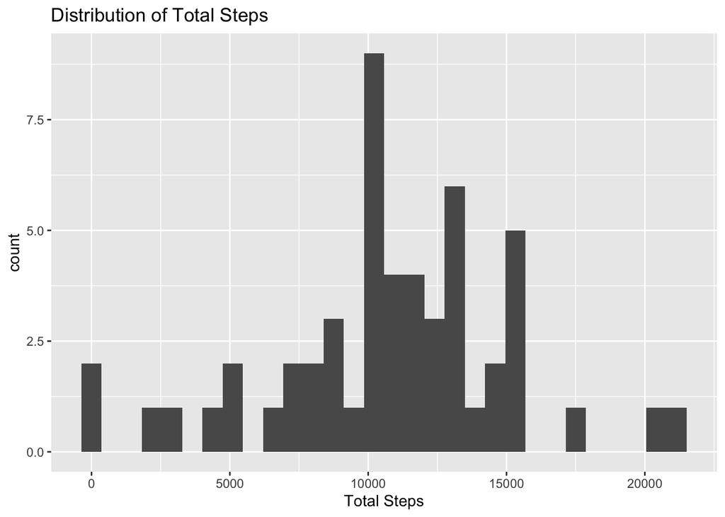

```r
ggplot(df1, aes(total)) + geom_histogram() +
  labs(title = "Distribution of Total Steps", x="Total Steps")
```

```r
mean_steps <- mean(df1$total, na.rm = TRUE)
median_steps <- median(df1$total, na.rm = TRUE)
summary(df1)
```

```
##      date               total
##  Length:61          Min.   :   41
##  Class :character   1st Qu.: 8841
##  Mode  :character   Median :10765
##                     Mean   :10766
##                     3rd Qu.:13294
##                     Max.   :21194
##                     NA's   :8
```

##What is the average daily activity pattern?

To show the daily activity pattern, I’ve grouped the original dataframe by five-minute interval, taken the average of the values on those intervals, and then plotted the averages over the course of the day.

There’s a big jump in average steps in the 0830-0900 timeframe, with the max showing up at 0835. However, the data may be skewed by the fact that we’re missing a total of 2304 values from our data (all in steps).

```r
df2 <- df %>% group_by(interval) %>% summarise(avg=mean(steps, na.rm = TRUE))
```

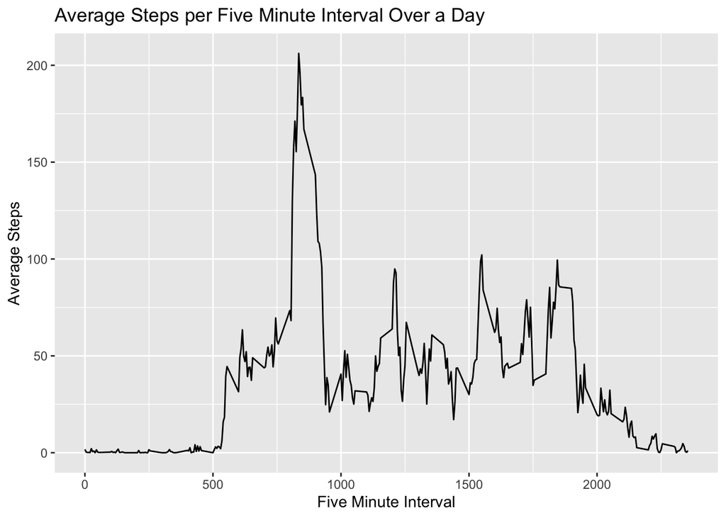

```r
ggplot(df2, aes(interval, avg)) + geom_line() +
  labs(title="Average Steps per Five Minute Interval Over a Day",
  x="Five Minute Interval", y="Average Steps")
```

```r
max_interval_row <- df2[which.max(df2$avg),]

total_nas <- sum(is.na(df$steps))
```

##Imputing missing values

To deal with the missing values, I’ve decided to impute the average for a given interval to fill in the gaps. Replacing missing values with the average seemed like a simple and effective way to make the data more useable.

As you can see by comparing with the data above, imputing values didn’t change th mean or median significantly, but the first and third quartiles changed and the plot looks significantly different.

```r
df <- df %>% mutate(impute_steps = ifelse(is.na(steps), df2$avg[match(interval, df2$interval)], steps))

df3 <- df %>% group_by(date) %>% summarise(total=sum(impute_steps))
summary(df1)
```

```
##      date               total
##  Length:61          Min.   :   41
##  Class :character   1st Qu.: 8841
##  Mode  :character   Median :10765
##                     Mean   :10766
##                     3rd Qu.:13294
##                     Max.   :21194
##                     NA's   :8
```

```r
summary(df3)
```

```
##      date               total
##  Length:61          Min.   :   41
##  Class :character   1st Qu.: 9819
##  Mode  :character   Median :10766
##                     Mean   :10766
##                     3rd Qu.:12811
##                     Max.   :21194
```

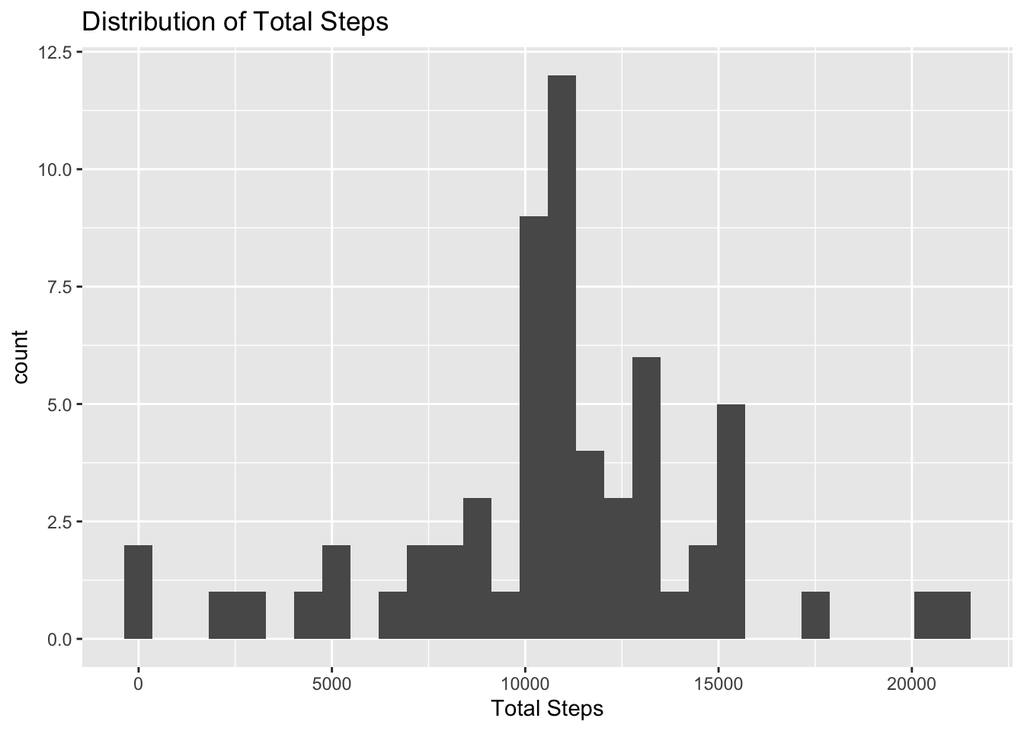

```r
ggplot(df3, aes(total)) + geom_histogram() +
  labs(title = "Distribution of Total Steps", x="Total Steps")
```

##Are there differences in activity patterns between weekdays and weekends?

To compare activity patterns on weekdays and weekends, first I converted the date column in the original dataframe to POSIXlt format and then wrote a function to check whether each date was a weekend and assign a value accordingly under the factor day_type.

I then grouped the full data (with imputed values from above) by day_type and interval, and used facet_grid in ggplot to plot weekend and weekday average activity levels.

```r
df$date <- as.POSIXlt(df$date)

weekly <- function(x) {
  ifelse(weekdays(x) %in% c("Saturday", "Sunday"), "weekend", "weekday")
}

df <- df %>% mutate(day_type = weekly(df$date))

df4 <- df %>% group_by(day_type, interval) %>% summarise(avg=mean(impute_steps))
```

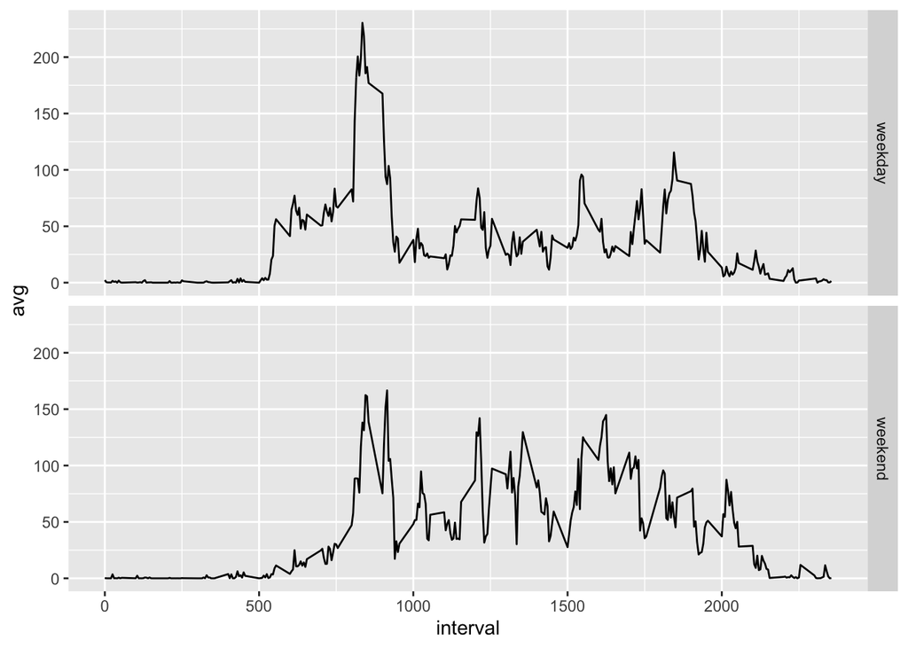

```r
ggplot(df4, aes(interval, avg)) + geom_line() + facet_grid(day_type ~ .)
```